# Assignment 5

#Preliminaries(1)

```r
install.packages("rstatix", dependencies = TRUE)
library(tidyverse)
library(ggthemes)
library(rstatix)
library(ggpubr)

assignment5 = read_csv("assignment5_data.csv")
```

#Subject-level means(2)

```r
subject_accuracy = assignment5 %>% group_by(subject, prime_condition) %>% summarise(mean_acc = mean(accuracy))
```

[output not shown]

```r
subject_rt = assignment5 %>% group_by(subject, prime_condition) %>% summarise(mean_rt = mean(response_RT))
```

[output not shown]

#Format of the data(3) Both subject_accuracy and subject_rt are currently in long format.

#Long to Wide Conversion(4)

```r
subject_accuracy_wide = subject_accuracy %>% pivot_wider(names_from = c(prime_condition), values_from=mean_acc)
```

#Wide to Long Conversion(5)

```r
subject_accuracy_long = subject_accuracy_wide %>%  pivot_longer(names_to = "prime_condition", cols = both:unrelated) %>% rename(mean_acc = value)
```

#Interpretation(6) subject_accuracy_long contains the same information as the original subject_accuracy dataframe.

#t-test in R

```r
t.test(subject_accuracy_wide$phonological, subject_accuracy_wide$semantic, var.equal = FALSE, paired = TRUE)
```

```
    Paired t-test

data:  subject_accuracy_wide$phonological and subject_accuracy_wide$semantic
t = 4.4075, df = 36, p-value = 9.033e-05
alternative hypothesis: true mean difference is not equal to 0
95 percent confidence interval:
 0.0706192 0.1910024
sample estimates:
mean difference
      0.1308108
```

#t-test interpretation(8) The t-test shows a p-value that is less than alpha. Based on this, there is a significant difference in the mean accuracy of subjects between the phonological and semantic prime conditions.

#t-test manual(9)

```r
subject_accuracy_wide = subject_accuracy_wide %>% mutate(diff = phonological - semantic)

x_bar = mean(subject_accuracy_wide$diff)
s_diff = sd(subject_accuracy_wide$diff)
n = nrow(subject_accuracy_wide)
df = n-1

t_denominator = s_diff/sqrt(n)
t = x_bar/t_denominator

p_value = 2*(1-pt(t,df))
```

#t-test outliers(10)

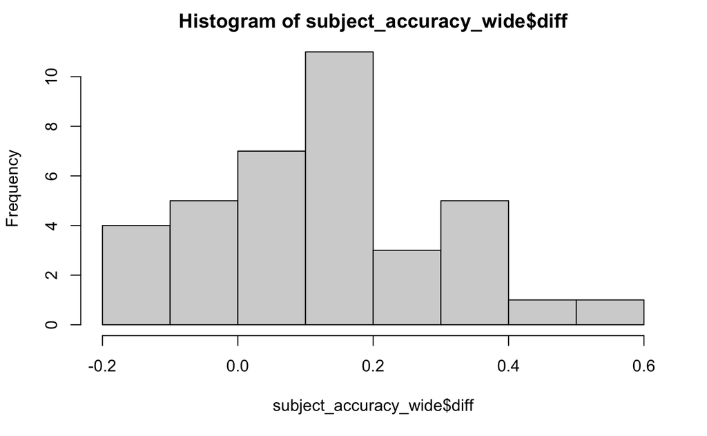

```r
subject_accuracy_wide = subject_accuracy_wide %>% ungroup()
hist(subject_accuracy_wide$diff)
```

```r
outliers = subject_accuracy_wide %>% identify_outliers(diff)
#there is one outlier in the data

outlier_subs = outliers %>% pull(subject)
newdf = subject_accuracy_wide %>% filter(!subject%in% outlier_subs)
```

#t-test normality(11)

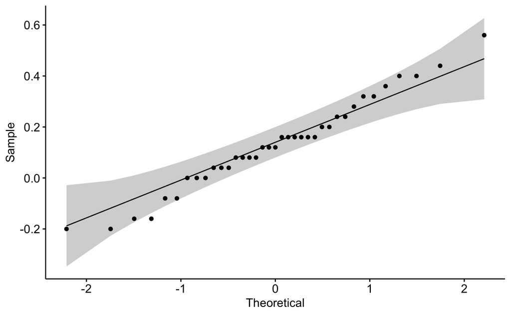

```r
ggqqplot (subject_accuracy_wide, "diff")
```

```r
subject_accuracy_wide %>% shapiro_test (diff)
```

| variable | statistic | p |
| --- | --- | --- |
| diff | 0.9787041 | 0.6864971 |

#Overall pattern interpretation(12) The test of assumptions does not change my conclusions about the validity of the t-test. Althought there was one outlier, this outlier was not extreme. Additionally, the differences appear to be normally distributed. Based on these assumptions being satisfied, we can conclude that there was an effect of prime condition on accuracy of response. In general, phonologically related cues enhance accuracy of response retrieval compared to semantically related cues.